# Week 8 Milestone Analysis

Author

Dairy Cow Foot Doc

Published

January 5, 2026

# Report for Herd 2108e

- This report shows data from the past year from **Oct 05, 24 to Oct 05, 25**.
- For the culling analysis cows were censored on Oct 05, 25 if they were not culled before this date.

## Objective

Your objective is to recreate the solution_data by doing the following with the events_formatted and animals table.

1. Filter the events_formatted table to only include LAME and TRIM events
2. Then create new variables for lesions using the **fxn_code_lesions()** function that you used from Github last milestone
   - This function is automatically loaded for you already.
   - use (protocol_var = protocols_letters1, remark_var = remark_letters1) inside the function
3. Address the abscess warning in the function by coding anything with ab in remark_letters1 or protocol_letter1 as noninf and remove them from other.
4. Run the following 3 functions to process the lesion data further and create variables you will need to use later on.
   - **fxn_collapse_lesions**(lesions = all_lesions)
   - **fxn_trim_vars**(location_event, id_animal, date_var = date_event, trimonly_var = trimonly)
   - **fxn_dz_status**(disease_cols = diseases, event_filter = trimonly == 0, gap = 1)
     - **NOTE**: All the other functions are specific for lameness this one is **NOT** and can be used for other diseases!
5. Then join this data table with the animals table to get the date_left, date_sold and date_died variables
6. Then create new culling variables as described below
   - **date_censor :** this is the last date the cow would have been eligible to be culled and should be the last date and event was entered in the data set
   - **days_to_cull:** days from event(trimming) to culling
   - **days_censor_cull:** days from event to culling or censor_date if not culled
   - **culled_ever:** 1 if the cow was culled, 0 if not culled
   - **culled_last_trim:** 1 if the cow was culled after her trim without being trimmed again.
   - **culled_30**: 1 if the cow was culled <=30 days after her trim 0 if not
7. Visualize this culling data
8. Create some summary statistics of this data using both logistic regression and compare that the provided survival analysis functions

## Your Code Creation

- The code block has some hints to help you create the solution_data data frame.

```r
# put your code here to create the required data frame.
# name it solution_data

# you will need to use these functions and vectors with these arguments at some point in your code.

all_lesions <- c("dd", "footrot", 'wld', "sole_ulcer","injury",
                             "cork", "other", "hemorrhage",
                             "sole_fracture", "toe_ulcer", "thin",
                             "inf", "noninf", "toe", "axial", "lesion")

diseases <- c("inf", "noninf", "lesion")

# solution_data <-

# fxn_collapse_lesions(lesions = all_lesions) |>
#   fxn_trim_vars(location_event, id_animal,
#                 date_var = date_event,
#                 trimonly_var = trimonly) |>
#   fxn_dz_status(disease_cols = diseases,
#                 event_filter = trimonly == 0)
```

```
✔ No differences
```

## Visualize Data

### Violin plot

Then on the solution_data table.

- Create a violin graph that shows the distribution of time to culling for cows with any lesion.
  - restrict data to
    - just the past 12 months
    - data from the cow’s last trimming
    - lactating cows only
    - positive days_to_censor_cull numbers only
- To compare your restricted data to the solution data use
  - *waldo::compare(log_data, restricted_data)*

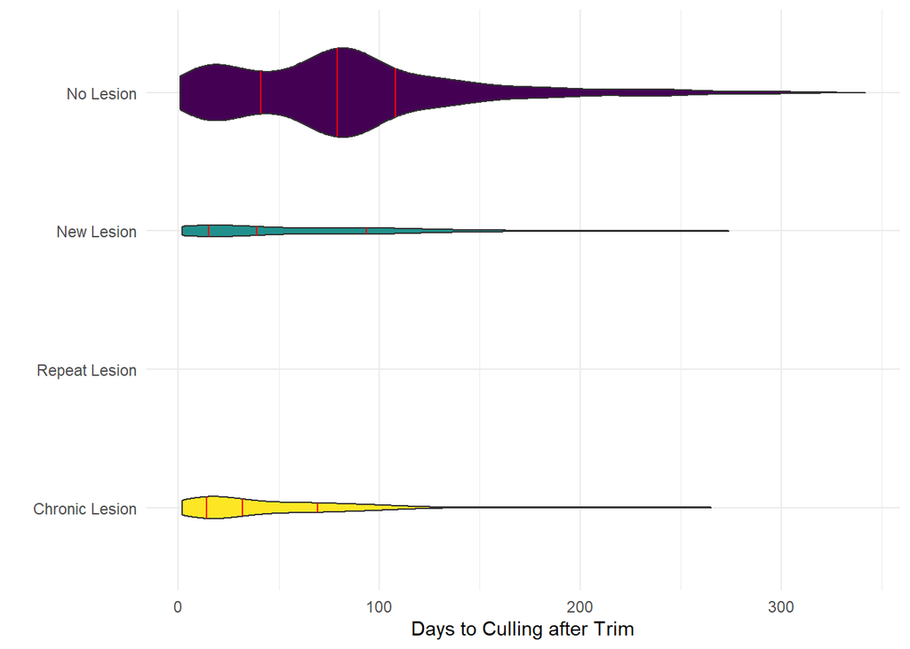

```r
# put your visualization category code here

solutions_violin()
```

### Heat Map

- For non infectious lesions create a heat map similar to this using the culled_30 variable.
- Restrict the data using the same criteria as above.

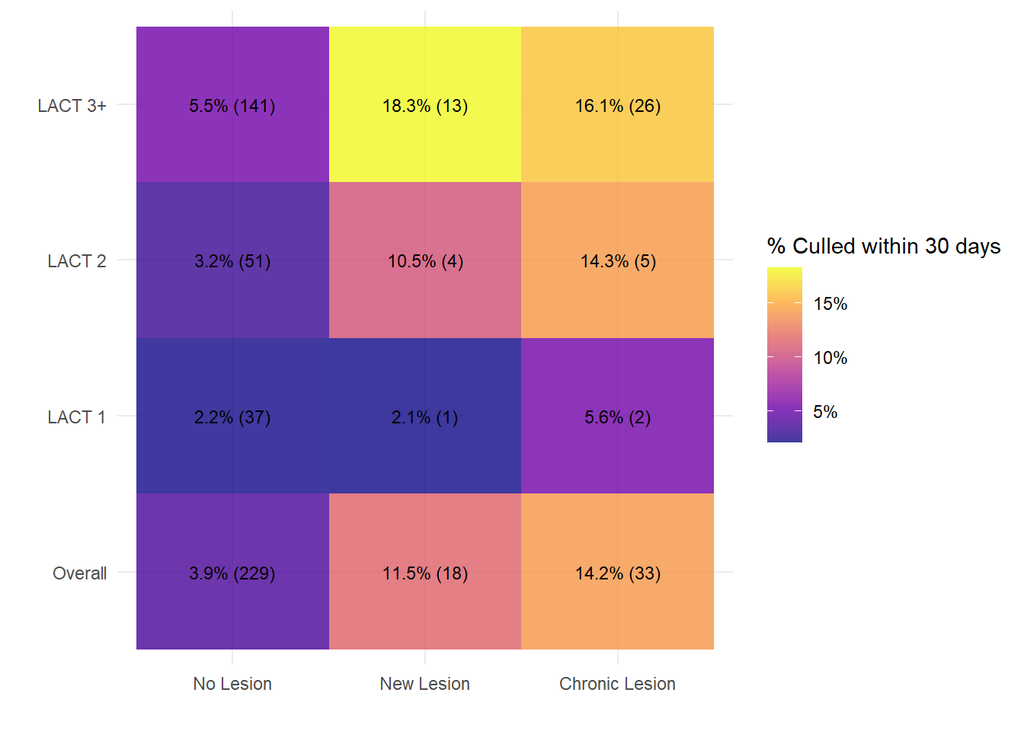

Figure 1

```r
solutions_heatmap()
```

# Modelling

At times it is useful to create a model to determine if the differences between culling risks between groups are important. Since we are modelling culling one approach is to use logistic regression to do this. Interpreting the outputs from these models can be harder to explain as typically they output odds ratios which aren’t commonly used by people other then researchers/data geeks. For this reason we should turn the model outputs back into risks.

In the section below create a logistic model that models the impact of non_infectious lesion status on culling at 30 days. - Name the model output log_model. _ Ignore lactation for this model. There are ways to account for lactation but we will keep it simple for now. - We have provide the code to make looking at the model output and to turn it into risks.

```r
log_model <- solutions_logistic()

log_model_results <- tidy(log_model, exponentiate = TRUE,
                      conf.int = TRUE) |>
  rename(oddsratio = estimate) |>
  mutate(
    # Format p-value to 4 decimal places
    p.value = number(p.value, accuracy = 0.00000001),
    # Optional: Format OR and CI for readability
    estimate = number(oddsratio, accuracy = 0.01),
    conf.low = number(conf.low, accuracy = 0.01),
    conf.high = number(conf.high, accuracy = 0.01)
  )

log_model_results |>
  gt()
```

| term | oddsratio | std.error | statistic | p.value | conf.low | conf.high | estimate |
| --- | --- | --- | --- | --- | --- | --- | --- |
| (Intercept) | 0.04076184 | 0.06741521 | -47.467166 | 0.00000000 | 0.04 | 0.05 | 0.04 |
| as_factor(noninf)New Lesion | 3.19992406 | 0.25951251 | 4.481969 | 0.00000740 | 1.86 | 5.19 | 3.20 |
| as_factor(noninf)Chronic Lesion | 4.06824516 | 0.19968216 | 7.027226 | 0.00000000 | 2.71 | 5.94 | 4.07 |

Figure 2

### Logistic Model Risks

```r
log_model_risks <- avg_predictions(log_model,
                               variables = c("noninf"))

log_model_risks <- log_model_risks |>
  select(noninf,
    Risk = estimate,
         conf.low,
         conf.high) |>
  mutate(
    Risk = number(Risk*100, accuracy = 0.1),
    conf.low = number(conf.low*100, accuracy = 0.1),
    conf.high = number(conf.high*100, accuracy = 0.1)
  ) |>
  gt()

log_model_risks
```

| noninf | Risk | conf.low | conf.high |
| --- | --- | --- | --- |
| No Lesion | 3.9 | 3.4 | 4.4 |
| New Lesion | 11.5 | 6.5 | 16.6 |
| Chronic Lesion | 14.2 | 9.7 | 18.7 |

Figure 3

You will notice the risks from the logistic model should be the same as the overall row in the heat map, but now we have confidence intervals around them to give us a sense of the uncertainty of the risk.

## Survival Analysis

One problem with using logistic regression and risks to deal with culling is that we are likely underestimating the risk of culling since some cows may be censored before they are culled. In our example censoring would occur if it has not been 30 days since a cow was trimmed. A better approach to deal with this is to use survival analysis.

Below we have provided code to create a Kaplan Meier survival curve and table to look at the impact of non infectious lesions on culling risk over time. You will notice that the risk estimates are higher now that we are accounting for censoring. A good quick read about survival analysis can be found [here](https://www.emilyzabor.com/survival-analysis-in-r.html#kaplan-meier-plots)

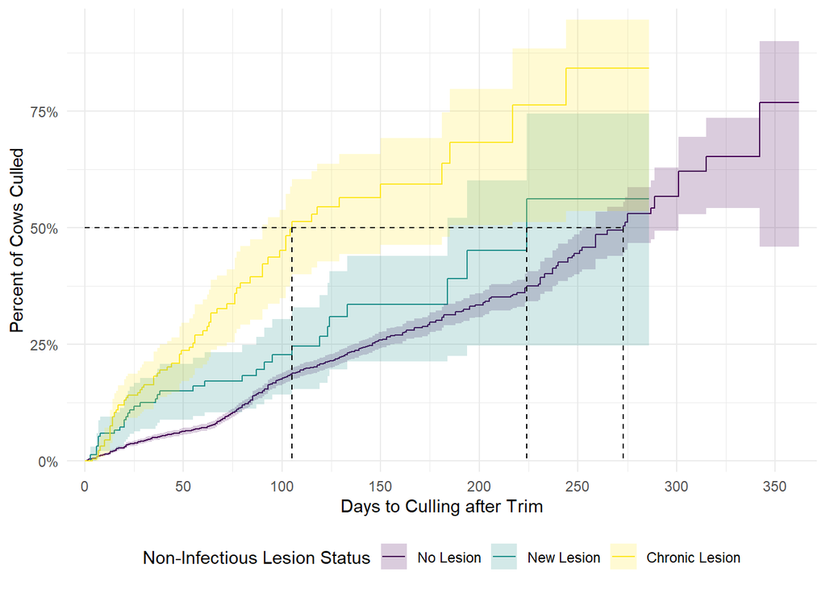

Figure 4

```r
# survival analysis
# km anaylsys


km_fit <- survfit2(Surv(time = days_to_censor_cull,
                event = culled_last_trim) ~ noninf,
data = log_data)

surv_plot <- km_fit |>
  ggsurvfit(
    type = "risk"
  )+
  add_confidence_interval()+
  add_quantile()+
  scale_ggsurvfit()+
  scale_fill_viridis_d(name = "Non-Infectious Lesion Status")+
  scale_color_viridis_d(name = "Non-Infectious Lesion Status")+
  labs(x = "Days to Culling after Trim",
       y = "Percent of Cows Culled")+
  theme_minimal()+
  theme(legend.position = "bottom")

surv_plot
```

```r
# times are adjustable

surv_table <- km_fit |>
  tbl_survfit(
    times = c(7, 30, 60, 180),
    label = " ",
    type = "risk",
    label_header = "{time} Days"
  ) %>%
  as_flex_table() %>% # makes formatting and pdf better
  add_header_row(
    top = TRUE,
    values = c(
      "Non-Infectious Lesion Status",
      "% Culled (Confidence Interval) at",
      "",
      "", ""
    )
  ) %>%
  bold(i = 1, bold = TRUE, part = "header") %>% # bolds headers
  bold(i = 2, bold = TRUE, part = "header") %>%
  merge_at(i = 1:2, j = 1, part = "header") %>% # merges 1st row
  merge_at(i = 1, j = 2:5, part = "header") # merges top columns

surv_table
```

| Non-Infectious Lesion Status | % Culled (Confidence Interval) at 7 Days | % Culled (Confidence Interval) at 30 Days | % Culled (Confidence Interval) at 60 Days | % Culled (Confidence Interval) at 180 Days |
| --- | --- | --- | --- | --- |
| No Lesion | 1.1% (0.8%, 1.4%) | 4.4% (3.8%, 4.9%) | 7.1% (6.4%, 7.9%) | 30% (28%, 32%) |
| New Lesion | 5.2% (1.6%, 8.7%) | 12% (6.9%, 18%) | 16% (9.6%, 22%) | 34% (21%, 44%) |
| Chronic Lesion | 2.2% (0.3%, 4.1%) | 16% (11%, 21%) | 28% (21%, 35%) | 59% (46%, 69%) |

Figure 5

# Extension

For this week extension continue to create standard things you would want to report or incorporate modeling techniques to explore the data

Ideas

- Try the code with other diseases like mastitis or culture information
- Try to use the survival code to get estimates for time to repeat or recheck?